# Amazon Fine Food Reviews Analysis

### [5.2.3] Applying KNN kd-tree on AVG W2V, SET 3

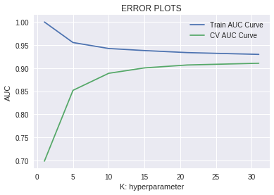

```python
# Please write all the code with proper documentation
from sklearn.metrics import roc_auc_score
train_auc= []
cv_auc= []
K = [1, 5, 10, 15, 21, 31]
for i in tqdm(K):
  neigh=KNeighborsClassifier(n_neighbors=i,algorithm="kd_tree")
  neigh.fit(train_vectors, Y_Train)
  y_train_pred=neigh.predict_proba(train_vectors)[:,1]
  y_cv_pred=neigh.predict_proba(cv_vectors)[:,1]
  train_auc.append(roc_auc_score(Y_Train,y_train_pred))
  cv_auc.append(roc_auc_score(Y_CV, y_cv_pred))

plt.plot(K, train_auc, label='Train AUC Curve')
plt.plot(K, cv_auc, label='CV AUC Curve')
plt.legend()
plt.xlabel("K: hyperparameter")
plt.ylabel("AUC")
plt.title("ERROR PLOTS")
plt.show()
```

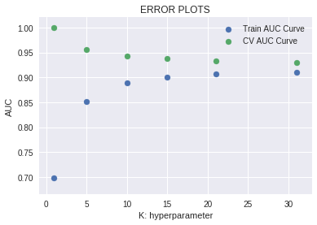

```python
# Distribution of K values
plt.scatter(K,cv_auc,label='Train AUC Curve')
plt.scatter(K,train_auc,label='CV AUC Curve')
plt.legend()
plt.xlabel("K: hyperparameter")
plt.ylabel("AUC")
plt.title("ERROR PLOTS")
plt.show()
```

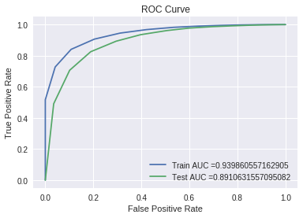

```python
optimal_k_avgw2v_KdTree = 13
neigh_bow=KNeighborsClassifier(n_neighbors=optimal_k_avgw2v_KdTree,algorithm="kd_tree")
neigh_bow.fit(train_vectors, Y_Train)

train_fpr,train_tpr,thresholds = roc_curve(Y_Train, neigh_bow.predict_proba(train_vectors)[:,1])
test_fpr, test_tpr, thresholds = roc_curve(Y_Test,  neigh_bow.predict_proba(test_vectors )[:,1])
train_avgw2v_kd_acc =auc(train_fpr, train_tpr)
test_avgw2v_kd_acc = auc(test_fpr, test_tpr)

plt.plot(train_fpr, train_tpr, label="Train AUC ="+str(train_avgw2v_kd_acc))
plt.plot(test_fpr, test_tpr, label="Test AUC ="+str(test_avgw2v_kd_acc))
plt.legend()
plt.xlabel("False Positive Rate")
plt.ylabel("True Positive Rate")
plt.title("ROC Curve")
plt.show()
```

```
Test confusion matrix
```

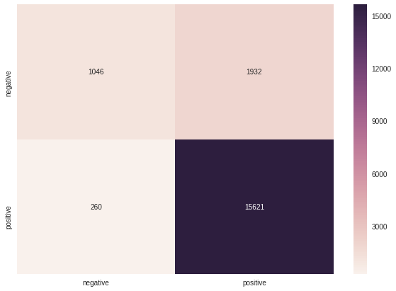

```python
class_names= ['negative','positive']
print("Test confusion matrix")
array = confusion_matrix(Y_Test, neigh.predict(test_vectors))

df_cm = pd.DataFrame(array, index = [i for i in class_names],columns = [i for i in class_names])
plt.figure(figsize = (10,7))
plt.xlabel("Actual Label")
plt.ylabel("Predicted Label")
sns.heatmap(df_cm, annot=True,fmt="d")
plt.show()
```

```
Train confusion matrix
```

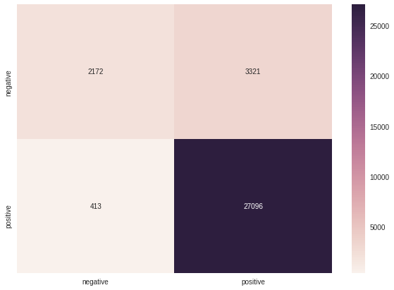

```python
class_names= ['negative','positive']
print("Train confusion matrix")
array = confusion_matrix(Y_Train, neigh.predict(train_vectors))

df_cm = pd.DataFrame(array, index = [i for i in class_names],columns = [i for i in class_names])
plt.figure(figsize = (10,7))
plt.xlabel("Actual Label")
plt.ylabel("Predicted Label")
sns.heatmap(df_cm, annot=True,fmt="d")
plt.show()
```

### [5.2.4] Applying KNN kd-tree on TFIDF W2V, SET 4

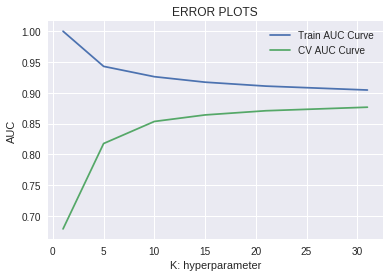

```python
# Please write all the code with proper documentation
from sklearn.metrics import roc_auc_score
train_auc= []
cv_auc= []
K = [1, 5, 10, 15, 21, 31]
for i in tqdm(K):
  neigh=KNeighborsClassifier(n_neighbors=i,algorithm="kd_tree")
  neigh.fit(tfidf_w2v_Train, Y_Train)

  y_train_pred=neigh.predict_proba(tfidf_w2v_Train)[:,1]
  y_cv_pred=neigh.predict_proba(tfidf_w2v_CV)[:,1]

  train_auc.append(roc_auc_score(Y_Train,y_train_pred))
  cv_auc.append(roc_auc_score(Y_CV, y_cv_pred))

plt.plot(K, train_auc, label='Train AUC Curve')
plt.plot(K, cv_auc, label='CV AUC Curve')
plt.legend()
plt.xlabel("K: hyperparameter")
plt.ylabel("AUC")
plt.title("ERROR PLOTS")
plt.show()
```

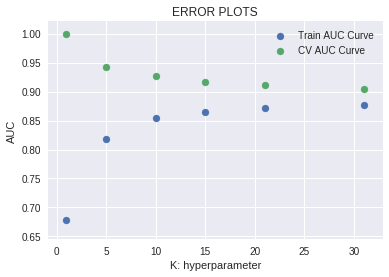

```python
# Distribution of K values
plt.scatter(K,cv_auc,label='Train AUC Curve')
plt.scatter(K,train_auc,label='CV AUC Curve')
plt.legend()
plt.xlabel("K: hyperparameter")
plt.ylabel("AUC")
plt.title("ERROR PLOTS")
plt.show()
```

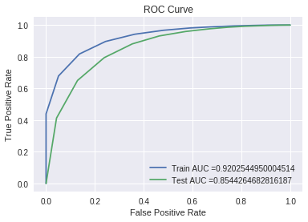

```python
optimal_k_tfidf_avgw2v_KdTree = 13
neigh_bow=KNeighborsClassifier(n_neighbors=optimal_k_tfidf_avgw2v_KdTree,algorithm="kd_tree")
neigh_bow.fit(tfidf_w2v_Train, Y_Train)

train_fpr,train_tpr,thresholds = roc_curve(Y_Train, neigh_bow.predict_proba(tfidf_w2v_Train)[:,1])
test_fpr, test_tpr, thresholds = roc_curve(Y_Test,  neigh_bow.predict_proba(tfidf_w2v_Test )[:,1])
train_tfidfw2v_kd_acc =auc(train_fpr, train_tpr)
test_tfidfw2v_kd_acc = auc(test_fpr, test_tpr)

plt.plot(train_fpr, train_tpr, label="Train AUC ="+str(train_tfidfw2v_kd_acc))
plt.plot(test_fpr, test_tpr, label="Test AUC ="+str(test_tfidfw2v_kd_acc))
plt.legend()
plt.xlabel("False Positive Rate")
plt.ylabel("True Positive Rate")
plt.title("ROC Curve")
plt.show()
```

```
Test confusion matrix
```

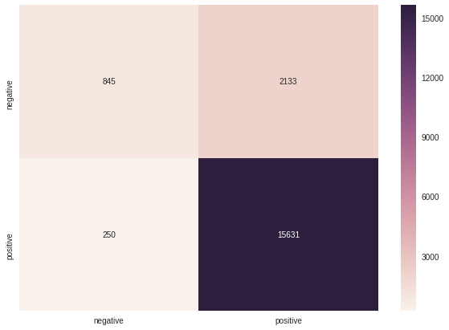

```python
class_names= ['negative','positive']
print("Test confusion matrix")
array = confusion_matrix(Y_Test, neigh.predict(tfidf_w2v_Test))

df_cm = pd.DataFrame(array, index = [i for i in class_names],columns = [i for i in class_names])
plt.figure(figsize = (10,7))
plt.xlabel("Actual Label")
plt.ylabel("Predicted Label")
sns.heatmap(df_cm, annot=True,fmt="d")
plt.show()
```

```
Train confusion matrix
```

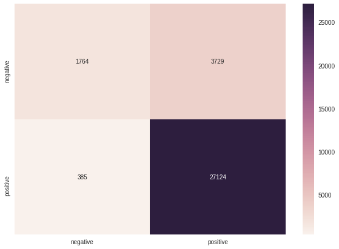

```python
class_names= ['negative','positive']
print("Train confusion matrix")
array = confusion_matrix(Y_Train, neigh.predict(tfidf_w2v_Train))

df_cm = pd.DataFrame(array, index = [i for i in class_names],columns = [i for i in class_names])
plt.figure(figsize = (10,7))
plt.xlabel("Actual Label")
plt.ylabel("Predicted Label")
sns.heatmap(df_cm, annot=True,fmt="d")
plt.show()
```

# [6] Conclusions

```python
# Please compare all your models using Prettytable library
from prettytable import PrettyTable

names= [
        "KNN using 'brute' for BoW",
		    "KNN using 'brute' for TFIDF",
		    "KNN using 'brute' for Avg-Word2Vec",
		    "KNN using 'brute' for TFIDF-Word2Vec",
		    "KNN using 'kdTree' for BoW",
		    "KNN using 'kdTree' for TFIDF",
		    "KNN using 'kdTree' for Avg-Word2Vec",
		    "KNN using 'kdTree' for TFIDF-Word2Vec"
		]


optimal_K= [
			optimal_k_bow_BruteForce,
			optimal_k_tfidf_BruteForce,
			optimal_k_avgw2vec_BruteForce,
			optimal_k_tfidfw2v_BruteForce,
			optimal_k_bow_KdTree,
			optimal_k_tfidf_KdTree,
			optimal_k_avgw2v_KdTree,
			optimal_k_tfidf_avgw2v_KdTree
			]

train_acc= [
			train_bow_acc,
			train_tfidf_acc,
			train_avgw2vec_acc,
			train_tfidfw2v_acc,
			train_bow_kd_acc,
			train_tfidf_kd_acc,
			train_avgw2v_kd_acc,
			train_tfidfw2v_kd_acc
			]

test_acc = [
			test_bow_acc,
			test_tfidf_acc,
			test_avgw2vec_acc,
			test_tfidfw2v_acc,
			test_bow_kd_acc,
			test_tfidf_kd_acc,
			test_avgw2v_kd_acc,
			test_tfidfw2v_kd_acc
 ]
numbering= [1,2,3,4,5,6,7,8]


# Initializing prettytable

ptable=PrettyTable()

 # Adding columns
ptable.add_column("S.NO.",numbering)
ptable.add_column("MODEL",names)
ptable.add_column("Best K",optimal_K)
ptable.add_column("Training Accuracy",train_acc)
ptable.add_column("Test Accuracy",test_acc)

# Printing the Table
print(ptable)
```

```
+-------+---------------------------------------+--------+--------------------+--------------------+
| S.NO. |                 MODEL                 | Best K | Training Accuracy  |   Test Accuracy    |
+-------+---------------------------------------+--------+--------------------+--------------------+
|   1   |       KNN using 'brute' for BoW       |   13   | 0.8661762331930533 | 0.7639291415598611 |
|   2   |      KNN using 'brute' for TFIDF      |   13   | 0.906895826364345  | 0.8051969083862436 |
|   3   |   KNN using 'brute' for Avg-Word2Vec  |   19   | 0.9353174665965203 | 0.8991522598249937 |
|   4   |  KNN using 'brute' for TFIDF-Word2Vec |   19   | 0.9126202789750149 | 0.8614007285295872 |
|   5   |       KNN using 'kdTree' for BoW      |   17   | 0.876543649349467  | 0.8232900472955992 |
|   6   |      KNN using 'kdTree' for TFIDF     |   13   | 0.8824177476378865 | 0.8172511458099907 |
|   7   |  KNN using 'kdTree' for Avg-Word2Vec  |   13   | 0.939860557162905  | 0.8910631557095082 |
|   8   | KNN using 'kdTree' for TFIDF-Word2Vec |   13   | 0.9202544950004514 | 0.8544264682816187 |
+-------+---------------------------------------+--------+--------------------+--------------------+
```

**Conclusion** :

1. I have taken 70000 data from SQL database.
2. After that I have cleaned the summary and text of the reviews.
3. Merge the Summary and text into new text column.
4. Sort the dataset based on time.
5. Split the dataset into Train, CV and Test.
6. Applied BOW, TFIDF, AVGW2V and TFIDF weighted W2V on review text.
7. Applied KNN using brute force on BOW,TFIDF, AVGW2V and TFIDF weighted W2V.
8. Implemented confusion matrix and AOC to find out accuracy.
9. Applied KNN using KD-Tree on BOW,TFIDF, AVGW2V and TFIDF weighted W2V
10. Implemented confusion matrix and AOC to find out accuracy.
11. Represent the best K, Training Accuracy and Test Accuracy in a taburar form.